# R Notebook

```r
tourism.data=readxl::read_xlsx("Tourism_new.xlsx")
head(tourism.data)
```

| TIME | Visitors Arrivals |
| --- | --- |
| 1987-03-01 | 132297 |
| 1987-04-01 | 108405 |
| 1987-05-01 | 95435 |
| 1987-06-01 | 105923 |
| 1987-07-01 | 127611 |
| 1987-08-01 | 119867 |

```r
dim(tourism.data)
```

```
[1] 397   2
```

```r
tail(tourism.data)
```

| TIME | Visitors Arrivals |
| --- | --- |
| 2019-10-01 | 944233 |
| 2019-11-01 | 1091946 |
| 2019-12-01 | 1225672 |
| 2020-01-01 | 1118150 |
| 2020-02-01 | 1015632 |
| 2020-03-01 | 328462 |

```r
# Monthly Seasonality (frequency set to 12 for monthly data)
tourism <- ts(tourism.data[,2],start= c(1997, 3),end = c(2020,3),frequency=12)
tourism
```

```
        Jan    Feb    Mar    Apr    May    Jun    Jul    Aug    Sep    Oct    Nov    Dec
1997               132297 108405  95435 105923 127611 119867 106016 132728 144678 148052
1998 149156 136776 138840 108804  94649 111381 136857 129419 109961 136294 162181 176343
1999 155633 142279 155497 114046 104237 120188 148884 135666 130581 170321 167134 191627
2000 177984 154758 149653 122986 107989 110033 143973 133941 128067 146263 151241 180270
2001 144177 114567 130878 113862 109988 114658 149215 141830 122693 158942 174304 203098
2002 177475 167268 148559 134895 123446 124385 160971 153529 139746 174622 189573 173182
2003 150019 149680 146191 118200 103371 118171 148225 136917 125693 165048 188877 214408
2004 192551 172642 187129 142501 120183 124908 168969 159519 133995 107609 156926 219501
2005 197343 187614 188252 146715 122918 128137 171458 159892 150261 196682 221524 252887
2006 224029 219635 196196 158785 132833 133154 176347 167985 160840 204126 240620 273310
2007 240569 227458 218411 154863 137536 143199 184324 176675 160032 210798 249275 270954
2008 245706 222089 215534 174204 137868 140810 175322 173095 160369 203903 239919 269810
2009 253125 241881 227151 165627 140168 153225 189045 184808 169200 219442 260752 277505
2010 253666 267403 234606 187419 151344 168716 204969 189902 181292 226531 275254 297711
2011 283750 262306 248965 185338 151098 176716 224432 196517 162326 181605 209685 254544
2012 228150 241133 216839 159789 144571 134566 178231 162594 163089 213267 245661 296474
2013 274215 262692 218473 160941 141508 176324 225359 204940 191339 260569 290583 319271
2014 337345 331697 293185 223884 185502 223122 272456 253301 226773 307447 385238 417527
2015 385977 369844 352094 248416 225394 246970 307870 273856 257184 347757 423837 479411
2016 459489 439090 391009 309208 255008 278370 337332 304387 297891 391399 442413 541571
2017 535631 501692 472494 350550 277017 310364 399866 358446 301892 444564 532428 596560
2018 511781 611493 479765 361101 304361 341539 431933 383337 341693 450013 531683 533904
2019 481308 489787 442062 347544 305183 352353 432900 369707 330707 458849 541524 615775
2020 568719 552152 512152
```

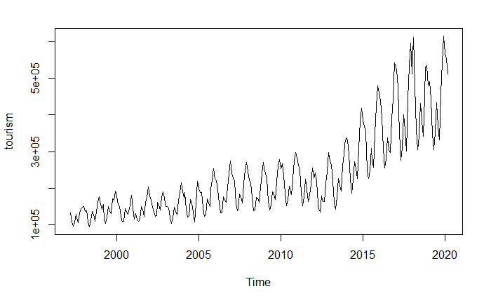

```r
plot(tourism)
```

The graph clearly shows a seasonality and an increasing trend i.e. a multiplicative variance. So to remove the variance, to convert it into a additive series, we need to find the log returns of the series. Let us first plot the log returns of the series and see how it looks.

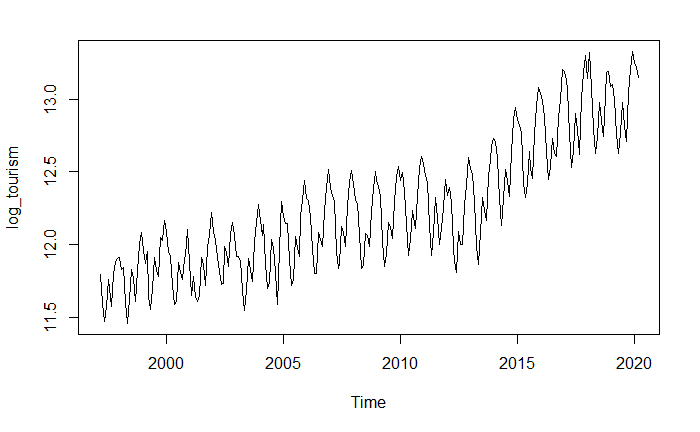

```r
log_tourism <- log(tourism)
plot(log_tourism)
```

We see that the variance has greatly reduced now. And now it shows a clear upward linearly increasing trend and seasonality. To remove the trend we can now apply diff() operator on the given time series. After applying difference lets plot and find out how it looks. As it has got both a trend and seasonality, so it seems that we need to apply both a simple difference diff(), and a seasonal difference operator diff(,12) with seasonality 12 to remove the trend and seasonality.

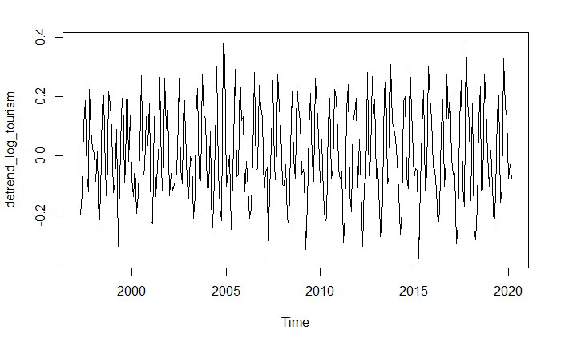

```r
detrend_log_tourism <- diff(log_tourism)
plot(detrend_log_tourism)
```

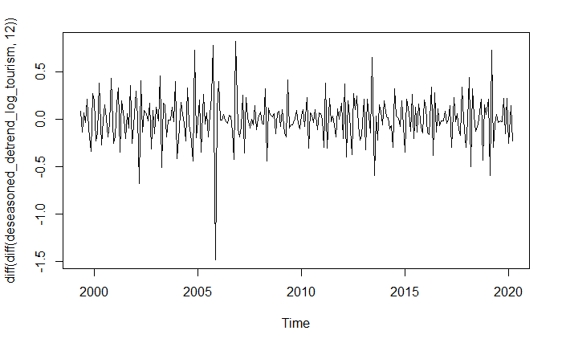

```r
deseasoned_detrend_log_tourism <- diff(detrend_log_tourism, 12)
plot(diff(diff(deseasoned_detrend_log_tourism,12)))
```

Now let us see if there is still any seasonality left. we shall check this using Dickey-Fuller Unit Root Test using package “urca”.

```r
library(urca)
summary(ur.df(diff(deseasoned_detrend_log_tourism,12), type = "none", lags = 1))
```

```
###############################################
# Augmented Dickey-Fuller Test Unit Root Test #
###############################################

Test regression none


Call:
lm(formula = z.diff ~ z.lag.1 - 1 + z.diff.lag)

Residuals:
     Min       1Q   Median       3Q      Max
-0.55187 -0.07792 -0.00018  0.07844  1.01876

Coefficients:
           Estimate Std. Error t value Pr(>|t|)
z.lag.1    -1.44507    0.09559 -15.118  < 2e-16 ***
z.diff.lag  0.21660    0.06208   3.489 0.000573 ***
---
Signif. codes:  0 ‘***’ 0.001 ‘**’ 0.01 ‘*’ 0.05 ‘.’ 0.1 ‘ ’ 1

Residual standard error: 0.1564 on 248 degrees of freedom
Multiple R-squared:  0.6127,    Adjusted R-squared:  0.6096
F-statistic: 196.2 on 2 and 248 DF,  p-value: < 2.2e-16


Value of test-statistic is: -15.1177

Critical values for test statistics:
      1pct  5pct 10pct
tau1 -2.58 -1.95 -1.62
```

```r
library(urca)
summary(ur.df(diff(deseasoned_detrend_log_tourism,12), type = "trend", lags = 12))
```

```
###############################################
# Augmented Dickey-Fuller Test Unit Root Test #
###############################################

Test regression trend


Call:
lm(formula = z.diff ~ z.lag.1 + 1 + tt + z.diff.lag)

Residuals:
     Min       1Q   Median       3Q      Max
-0.44543 -0.05846  0.00294  0.06032  0.65660

Coefficients:
               Estimate Std. Error t value Pr(>|t|)
(Intercept)  -3.603e-03  1.641e-02  -0.220 0.826431
z.lag.1      -2.445e+00  3.316e-01  -7.374 3.18e-12 ***
tt            3.351e-05  1.102e-04   0.304 0.761456
z.diff.lag1   1.224e+00  3.077e-01   3.979 9.35e-05 ***
z.diff.lag2   1.002e+00  2.978e-01   3.365 0.000899 ***
z.diff.lag3   9.402e-01  2.833e-01   3.319 0.001055 **
z.diff.lag4   9.114e-01  2.689e-01   3.389 0.000828 ***
z.diff.lag5   8.294e-01  2.508e-01   3.307 0.001100 **
z.diff.lag6   7.594e-01  2.288e-01   3.320 0.001052 **
z.diff.lag7   7.528e-01  2.037e-01   3.695 0.000276 ***
z.diff.lag8   7.818e-01  1.782e-01   4.389 1.76e-05 ***
z.diff.lag9   8.622e-01  1.528e-01   5.642 5.06e-08 ***
z.diff.lag10  7.603e-01  1.263e-01   6.022 7.00e-09 ***
z.diff.lag11  7.613e-01  9.308e-02   8.179 2.13e-14 ***
z.diff.lag12  1.106e-01  6.680e-02   1.656 0.099140 .
---
Signif. codes:  0 ‘***’ 0.001 ‘**’ 0.01 ‘*’ 0.05 ‘.’ 0.1 ‘ ’ 1

Residual standard error: 0.1175 on 224 degrees of freedom
Multiple R-squared:  0.7956,    Adjusted R-squared:  0.7828
F-statistic: 62.28 on 14 and 224 DF,  p-value: < 2.2e-16


Value of test-statistic is: -7.3742 18.1654 27.2303

Critical values for test statistics:
      1pct  5pct 10pct
tau3 -3.98 -3.42 -3.13
phi2  6.15  4.71  4.05
phi3  8.34  6.30  5.36
```

Here we previously we have detrended the data, so applied ADF test using type = “none” with lag 1. The p value for z.lag.1 is far below 0.001, which shows that we can reject the NULL Hypothesis in favour of the alternate hypothesis. Which means that Unit root is not present and the data is stationary.